# Mock Exam

English Morphology

Fernanda Barrientos

November 2024

### Single choice

Only one answer is correct. 1p each.

**1. What is a morpheme?**

A unit of meaning that can stand on its own a minimal unit of meaning a word with two or more units of meaning a word form that remits to a single, simpler meaning

**2. When we talk about the mental lexicon, we mean...**

a list of morphemes in our language as well as the combinatory rules to create new word forms the set of rules that allows to create and understand new words the full list of words in our language, derived and underived the full list of lexemes in a language, regardless of whether you have heard them before or not

**3. "A concrete occurrence of a given word form in a text" is a good definition for the concept of...**

morpheme token type lexeme

**4. Which of the following is an example of *inflection*?**

case clipping derivation exocentric compounding

**5. Which of the following is an example of clipping (i.e. portmanteau)?**

Kleenex internationalize Spork pescetarian

**6. Which of the following is NOT a process of LEXEME formation?**

Templatic morphology Evidentiality Compounding Affixation

**7. Which of the following inflectional categories is NOT present in English AT ALL?**

Number Aspect Case Tense

**8. A language wherein one morpheme carries a lot of information (e.g. case, number, TAM) is called:**

isolating polysynthetic agglutinative fusional

**9. Look at the following examples from Finnish and Hungarian (both Finno-Ugric). What is the difference between both in terms of possessive marking?**

as ember ház-a the man house-3SG.

isä-n talo dad-Gen house

Hungarian shows head-marking and Finnish has dependent-marking Possessives in Finnish are marked inflectionally, whereas Hungarian does it periphrastically Finnish has head-marking and Hungarian has dependent-marking Possessives in Hungarian are marked inflectionally, whereas Finnish does it periphrastically

**10. Transitive verbs:**

Can take only subjects Are crucial for assigning case to a subject in ergative systems Can never be used for building sentences with continuative aspect Have a particular paradigm

**11. Which if these statements is FALSE?**

Languages that don't inflect for a certain category may still express the same idea periphrastically Affixation is only possible in derivation, never in inflection English used to have a case system, with categories that were similar to those of present day German Derivation is always closer to the base than inflection

**12. Which of the following trees is the right way to represent the word "undoable" in the sense of something that can be undone?**

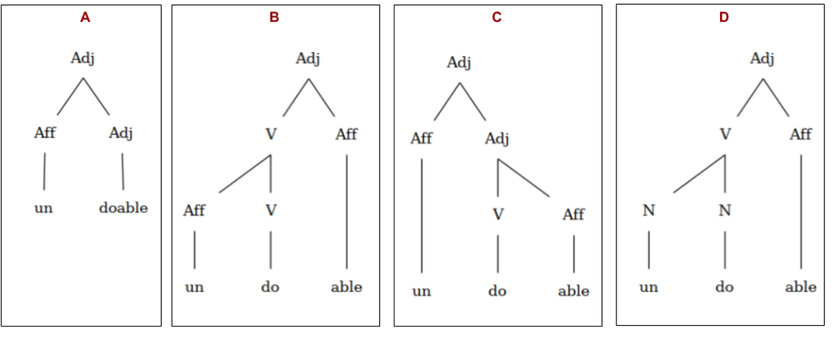

A B C D

**13. The past tense of the verb *to shoot* is a case of:**

Derivation by ablaut Inflection by affixation Inflection by ablaut Inflection by stem change and affixation

**14. What is the main issue of morpheme-based approaches to formalizing morphological rules?**

It cannot account very well for processes that are not affixation Cannot use tree structures to represent affixation Works well only for templatic morphology Focuses too much on non concatenative processes

**15. Which of the following may be a restriction to productivity?**

The level of creativity of the speakers The amount of hapaxes found in a language The phonological structure of the base The degree of lexicalization of the base

**16. An example of syntactic restriction to productivity is:**

Some affixes may attach only to Latin words Some affixes may attach only to words with a positive meaning Some affixes may attach only to polysyllabic bases Some affixes cannot attach to transitive verbs

**17. An example of syntactic restriction to productivity is:**

Some affixes cannot attach to transitive verbs Some affixes may attach only to Latin words Some affixes may attach only to polysyllabic bases Some affixes may attach only to words with a positive meaning

**18. Which of the following could be an example of lexicalization?**

Any endocentric compound A derived word where the morphemes are clearly transparent, such as *beautiful* A derived word where the morphemes are analyzed as a single lexical unit, such as *leaflet* A lexeme whose meaning changed into a grammatical category, such as *let us* ('allow us') > *let's* (auxiliary)

**20. In Turkish, the word *çekoslovakya-lı-laş-tır-ama* means "unable to cause to become a Czech". This is just one word, and each of the morphemes (separated by dashes) carry one bit of meaning. This pattern is typologically known as:**

Agglutinative Fusional Polysynthetic Isolating

**21. "The number of arguments in a sentence, where arguments are noun phrases like the subject and object selected by the verb of the sentence". This definition corresponds to the concept of:**

Valency Ergativity Multiple exponence Causativity

**22. In anti-passive sentences:**

Removes the subject periphrastically Turns the objects of the sentence in ergatives The addition of a morpheme allows to turn a transitive into an intransitive verb Turns the agent into the patient, and *vice versa*

**23. What do applicative and causative morphology have in common?**

They add arguments to the valency of a verb They incorporate pronouns to verbs They incorporate nouns to the verb They remove arguments to the valency of a verb

**24. In English, what is the effect of the prefix over- on the verb?**

It may turn a transitive verb into an intransitive one It may turn an intransitive verb into a transitive one It may change the valency of the verb All are correct

**25. In Spanish, one can say *pásamelo* ('give it to me'), where *me* and *lo* are dative and accusative pronouns, respectively. These pronouns are:**

Proclitics Forming a phrasal compound Enclitics Parts of a phrasal verb

**26. In English, we can say "he has a very in-your-face attitude". This is an example of:**

A periphrastic expresion An endocentric attributive A phrasal compound A phrasal verb

**27. English uses the morpheme *-s* /z/ for the plural, which can be produced as [s] in *cats*, [z] in *dogs*, and [əz] in *churches*. It is FALSE that:**

The [z] form is due to nasal assimilation These allomorphs are predictable The [s] form is due to voicing assimilation The English plural morpheme has several allomorphs

**28. A heavy syllable is:**

All but the first option are correct A syllable with a long vowel A syllable with a complex onset at the beginning A syllable with a consonant at the end

**29. In English, the order of certain affixes matter, e.g. we can't have native suffixes attached before nonnative suffixes. This is because:**

They are rival affixes They refer to different lexical strata Nonnative suffixes have heavier syllables at the end Nonnative suffixes block native ones

**30. According to the Complexity Based Ordering hypothesis, what of the following characteristics should have an affix to attach to an already affixed word?:**

It must have cumulative expression It has to be infrequent It has to be transparent It has to belong to different strata

### Short answer (3p each)

**31. Look at the following word formation process found in Kannada, and write down the morphological correspondence between the noun and the "and the like" forms.**

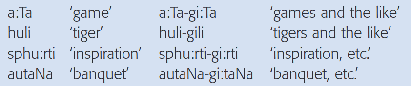

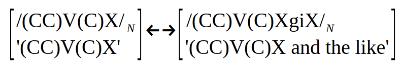

**32. Explain very briefly why the word *ungrammaticality* is an example of the bracketing paradox.**

Because according to the stratal ordering hypothesis, nonnative affixes (such as -ity) attach before native affixes, but un- cannot attach to nouns (i.e. it can't be un + grammaticality)

**33. Provide an example of suppletion, either from English or German. Briefly explain why this is the case.**

Example from English: go/went. Suppletion refers to bases with the same meaning but that are completely different to which other affixes attach to inflect.

**34. Provide an example of an exocentric compound, and explain why.** *

crankypants (meaning: a person who is in a bad mood). Exocentric compounds denote something that is not the meaning of the head (it doesn't refer to a type of pants).